# Regression and model validation

*This week’s topic is simple regression analysis with linear models and method validation. What follows is a short report on my results for Exercise 2 of the IODS course.*

The data used for this analysis is from the International Survey of Approaches to Learning, made possible by Teacher’s Academy funding for Kimmo Vehkalahti. Data were collected from 3.12.2014 to 10.01.2015 from students taking part in a statistics course. I created a subset of the data including variables on demographic characteristics and learning attitudes. The main interest of this analysis is the relationship between student’s learning approaches and exam outcomes.

```r
# read in previously prepared data
data <- read.table("data\\learning2014.csv", header = T, sep = ",")
# the first six rows of the data set
head(data)
```

```
##   gender Age Attitude     deep  stra     surf Points
## 1      F  53       37 3.583333 3.375 2.583333     25
## 2      M  55       31 2.916667 2.750 3.166667     12
## 3      F  49       25 3.500000 3.625 2.250000     24
## 4      M  53       35 3.500000 3.125 2.250000     10
## 5      M  49       37 3.666667 3.625 2.833333     22
## 6      F  38       38 4.750000 3.625 2.416667     21
```

My data set contains 166 observations and seven variables. Those being: **gender** (coded as a factor with the two levels male (M) and female (F)), **age** (in years, derived from the date of birth), **Points** (the student’s exam points in a statistics exam), a combination variable that measures the student’s general attitude toward statistics (**Attitude**), as well as three combination variables assessing different learning approaches:  
- Deep approach: the student wants to maximize their understanding and has a true commitment to learning (**deep**)  
- Surface approach: the student memorizes withour understanding and lacks personal engagement in the learning process (**surf**)  
- Strategic approach: the student applys a strategy that maximises the chance of achieving the highest possible grade (**stra**).

```r
# row and column numbers of the data set
dim(data)
```

```
## [1] 166   7
```

All combination variables have been scaled to their original scales by taking the mean. The three learning approaches are coded numerically while **Attitude**, **Points**, and **age** are integer variables. Further, I excluded observations where the exam points variable is zero, meaning that the student did not attend the exam.

```r
# structure of the data set and it's variables
str(data)
```

```
## 'data.frame':    166 obs. of  7 variables:
##  $ gender  : chr  "F" "M" "F" "M" ...
##  $ Age     : int  53 55 49 53 49 38 50 37 37 42 ...
##  $ Attitude: int  37 31 25 35 37 38 35 29 38 21 ...
##  $ deep    : num  3.58 2.92 3.5 3.5 3.67 ...
##  $ stra    : num  3.38 2.75 3.62 3.12 3.62 ...
##  $ surf    : num  2.58 3.17 2.25 2.25 2.83 ...
##  $ Points  : int  25 12 24 10 22 21 21 31 24 26 ...
```

```r
# load necessary libraries
library(ggplot2)
library(GGally)
```

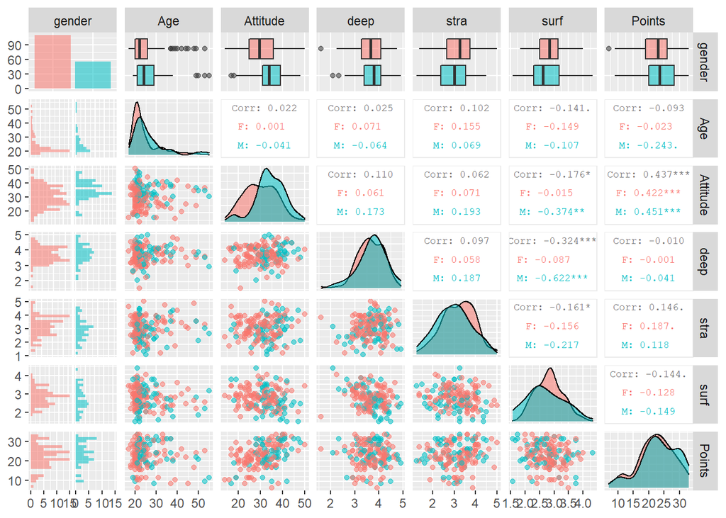

```r
# plot
ggpairs(data, mapping = aes(col = gender, alpha = 0.3), lower = list(combo = wrap("facethist", bins = 20)),
        upper = list(continuous = wrap("cor", size = 2.5)))
```

Further, I looked at summary measures for each variable. The exploration of the data shows that around 66% of the students are female and the majority of students is in it’s early to mid-20s. However, the oldest student is a 55 years old man. On average, students attending the exam scored 22.7 points.

```r
summary(data$gender)
```

```
##    Length     Class      Mode
##       166 character character
```

```r
summary(data$Age)
```

```
##    Min. 1st Qu.  Median    Mean 3rd Qu.    Max.
##   17.00   21.00   22.00   25.51   27.00   55.00
```

```r
summary(data$Attitude)
```

```
##    Min. 1st Qu.  Median    Mean 3rd Qu.    Max.
##   14.00   26.00   32.00   31.43   37.00   50.00
```

```r
summary(data$deep)
```

```
##    Min. 1st Qu.  Median    Mean 3rd Qu.    Max.
##   1.583   3.333   3.667   3.680   4.083   4.917
```

```r
summary(data$stra)
```

```
##    Min. 1st Qu.  Median    Mean 3rd Qu.    Max.
##   1.250   2.625   3.188   3.121   3.625   5.000
```

```r
summary(data$surf)
```

```
##    Min. 1st Qu.  Median    Mean 3rd Qu.    Max.
##   1.583   2.417   2.833   2.787   3.167   4.333
```

```r
summary(data$Points)
```

```
##    Min. 1st Qu.  Median    Mean 3rd Qu.    Max.
##    7.00   19.00   23.00   22.72   27.75   33.00
```

To answer the question which of the variables have an effect on a student’s exam points, I fitted a linear regression model with **Points** as the target variable and **Attitude**, **Age**, and **stra** as the explanatory variables. I chose these variables based on the correlations from the ggpairs plot. I did not include **surf** because one of the seven classical assumptions of Ordinary Least Squares (OLS) linear regression is that the explanatory variables are independent from each other. Given the correlation between **surf** and the other two learning approaches as well as **Attitude**, this assumption would be violated if I included **surf** in the model.

```r
# linear regression model  with three explanatory variables
model1 <- lm(Points ~ Attitude + Age + stra, data = data)
```

Regarding the interpretation of the model parameters, **Attitude** and **stra** are positively and **Age** is negatively correlated with the exam points. If the measure for the general attitude toward statistics increases by one unit (more positively toward statistics), the average increase in exam points is 0.35 points, while assuming that the other variables stay constant. Further, with every year of age, the exam score decreases on average by 0.09 points. And lastly, having one unit more of an strategic learning approach increases the exam points by one point on average. However, the standard error for the **stra** coefficient is quite big compared to the others (Std. Error of 0.53 vs. 0.06 (Attitude) and 0.05 (Age)). An interpretation of the intercept would not contain any meaningful information.

```r
summary(model1)
```

```
##
## Call:
## lm(formula = Points ~ Attitude + Age + stra, data = data)
##
## Residuals:
##      Min       1Q   Median       3Q      Max
## -18.1149  -3.2003   0.3303   3.4129  10.7599
##
## Coefficients:
##             Estimate Std. Error t value Pr(>|t|)
## (Intercept) 10.89543    2.64834   4.114 6.17e-05 ***
## Attitude     0.34808    0.05622   6.191 4.72e-09 ***
## Age         -0.08822    0.05302  -1.664   0.0981 .
## stra         1.00371    0.53434   1.878   0.0621 .
## ---
## Signif. codes:  0 '***' 0.001 '**' 0.01 '*' 0.05 '.' 0.1 ' ' 1
##
## Residual standard error: 5.26 on 162 degrees of freedom
## Multiple R-squared:  0.2182, Adjusted R-squared:  0.2037
## F-statistic: 15.07 on 3 and 162 DF,  p-value: 1.07e-08
```

To validate my model I plotted three different residual diagnostics. With these plots I am able to validate four model assumptions regarding the residuals:  
- The errors are normally distributed –> *QQ-plot*  
- The errors are not correlated –> *Residuals vs. Fitted*  
- The errors have constant variance, and the size of a given error does not depend on the explanatory variables –> *Residuals vs. Fitted*.  
In addition, using the *Residuals vs. Leverage* plot, shows whetehr there single observation that have too much impact on the regression line.

The first plot shows the residuals plotted against the fitted values from the model. Because there is no visible pattern in the residuals, I think that the assumptions on error normality, error correlation, constant variance of errors as well as the independence of errors from the explanatory variables are not violated. Further, the standardized residuals adequately follow the line in the QQ-plot. Last but not least, none of the observations is having an outlying strong impact on the regression results, as shown by *Residuals vs. Leverage*.

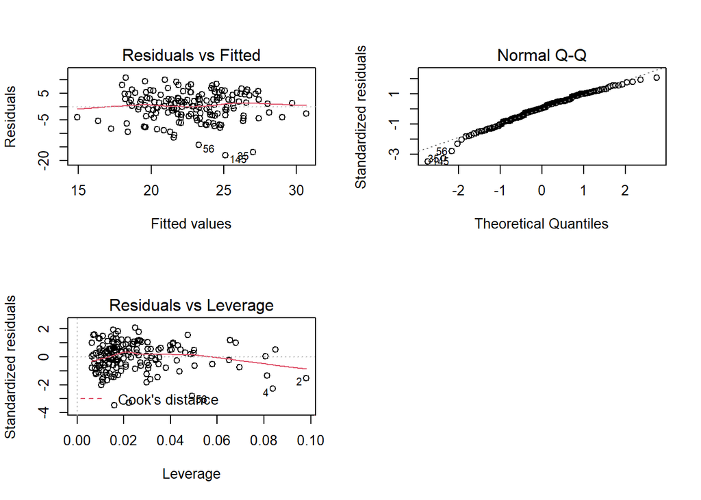

```r
par(mfrow = c(2,2))
plot(model1, which = c(1, 2, 5))
```